# Chap 7.7

Mijeong Kim

```r
library(tsibble)
library(tsibbledata)
library(tibble)
library(dplyr)
library(knitr)
library(ggplot2)
library(fpp3)
library(fpp2)
library(seasonal)
library(feasts)
library(GGally)
```

## 7.7 Nonlinear regression

#### 1. 비선형 관계의 필요성

- 대부분의 경우 선형 회귀로 충분하지만, **일부 변수 간에는 비선형 함수 형태가 더 적합**하다.
- 단순화를 위해 이 절에서는 **하나의 예측 변수 $x$**만 고려한다.

#### 2. 로그 변환을 통한 비선형 모델

- 비선형 관계를 다루는 가장 간단한 방법은 **변수 $y$, $x$를 변환**하여 선형 회귀 모델을 적용하는 것이다.
- 가장 일반적인 변환은 **자연로그 변환**이다.

#### 주요 형태:

- **Log-log 모델**:
  $$\log y = \beta_0 + \beta_1 \log x + \varepsilon$$
  → $\beta_1$은 **탄력성(elasticity)**으로 해석 가능:
  $x$가 1% 증가할 때 $y$의 평균 변화율
- **Log-linear 모델**: $\log y = \beta_0 + \beta_1 x + \varepsilon$
- **Linear-log 모델**: $y = \beta_0 + \beta_1 \log x + \varepsilon$

> 로그 변환을 위해서는 **0보다 큰 값**만 가능하며, $\log(x + 1)$을 사용하면 0을 포함하는 데이터도 변환 가능하다.

#### 3. 일반 비선형 함수 $f(x)$

- 단순 변환만으로 충분하지 않다면, 보다 일반적인 비선형 함수 $f(x)$를 사용한다:
  $$y = f(x) + \varepsilon$$
- 선형 회귀에서는 $f(x) = \beta_0 + \beta_1 x$이며,  
  비선형 회귀에서는 $f(x)$가 더 유연한 형태가 된다.

#### 4. Piecewise Linear (단절점 기반 회귀)

- $f(x)$를 **부분적으로 선형(piecewise linear)**하게 만들 수 있다.
- 특정 지점 $c$에서 기울기를 바꾸기 위해 다음과 같이 정의:

$$x_1 = x, \quad x_2 = (x - c)^+ =
\begin{cases}
0 & \text{if } x < c \\
x - c & \text{if } x \geq c
\end{cases}$$

- 이 구조를 사용하면, **기울기가 $c$에서 꺾이는 모델**을 만들 수 있다.

이 변수를 이용하면 다음과 같은 회귀모형을 적합할 수 있다.

$$y = \beta_0 + \beta_1 x + \beta_2 (x-c)^+ + \varepsilon$$

이 모형은 $x<c$와 $x \ge c$에서 서로 다른 기울기를 갖는다.

##### $x<c$인 경우

이때는 $(x-c)^+ = 0$이므로 모형은

$$y = \beta_0 + \beta_1 x + \varepsilon$$

가 된다. 따라서 절단점 $c$ 이전 구간의 기울기는 $\beta_1$이다.

#### 5. 회귀 스플라인 (Regression Splines)

위의 piecewise linear 모델은 회귀 스플라인(regression splines)의 가장 단순한 형태 중 하나이다.  
하나의 절단점만 쓰는 대신, 여러 개의 절단점(knots)을 사용하면 더 복잡한 비선형 관계를 표현할 수 있다.

절단점이 $c_1, c_2, \dots, c_{k-1}$일 때,  
다음과 같은 기저함수(basis functions)를 정의한다.

$$x_1 = x, \qquad
x_2 = (x-c_1)^+, \qquad
x_3 = (x-c_2)^+, \qquad \dots \qquad
x_k = (x-c_{k-1})^+$$

이들을 이용한 회귀모형은 다음과 같다.

$$y = \beta_0 + \beta_1 x + \sum_{j=1}^{k-1} \beta_{j+1}(x-c_j)^+ +
\varepsilon$$

여기서

- $\beta_0$: 절편
- $\beta_1$: 첫 번째 구간의 기본 기울기
- $\beta_{j+1}$: 절단점 $c_j$ 이후에 추가되는 기울기 변화량

을 의미한다.

이 모형에서는 각 절단점을 지날 때마다 기울기가 한 번씩 바뀐다.  
따라서 전체적으로는 하나의 직선이 아니라, 여러 개의 선분이 연결된 형태의 함수를 적합하게 된다.

##### 직관적 해석

- 절단점이 없으면: 하나의 직선
- 절단점이 1개면: 한 번 꺾이는 직선
- 절단점이 여러 개면: 여러 번 꺾이는 직선

즉, 회귀 스플라인은 설명변수와 반응변수 사이의 관계를  
여러 구간에서 서로 다른 선형 관계로 표현하는 방법이다.

##### 왜 유용한가?

단순 선형회귀는 전체 구간에서 기울기가 일정하다고 가정한다.  
그러나 실제 데이터에서는 어떤 구간에서는 완만하게 증가하고,  
다른 구간에서는 급격히 증가하거나 거의 변하지 않을 수 있다.  
이럴 때 회귀 스플라인은 이러한 국소적 변화(local change)를 더 잘 반영할 수 있다.

##### 절단점(knots)의 역할

절단점 $c_1,\dots,c_{k-1}$는 선형 관계가 바뀌는 지점을 의미한다.  
절단점의 위치에 따라 모형의 형태가 크게 달라질 수 있으므로,  
절단점의 선택은 매우 중요하다.

하지만 실제로는 다음과 같은 어려움이 있다.

1. 절단점의 개수를 몇 개로 할지 결정해야 한다.
2. 절단점을 어디에 둘지 결정해야 한다.
3. 절단점이 너무 많으면 과적합(overfitting)이 발생할 수 있다.
4. 절단점이 너무 적으면 중요한 비선형 구조를 놓칠 수 있다.

일부 자동화된 선택 방법이 존재하지만,  
절단점의 수와 위치를 완전히 자동으로 정하는 것은 쉽지 않다.  
따라서 실무에서는 보통 도메인 지식, 데이터의 형태, 또는 단순한 기준을 함께 활용하여 절단점을 정한다.

### Forecasting with a nonlinear trend (비선형 추세 모델링)

#### 1. 선형 추세

- Section 7.4에서는 선형 추세를 다음과 같이 단순화하여 모델링하였다:

$$x_t = t$$

$$y_t = \beta_0 + \beta_1 t + \varepsilon_t$$
—

#### 2. 다항 추세 (비추천)

- **2차 또는 그 이상의 다항식**을 이용한 추세 모델링:

$$x_{1,t} = t, \quad x_{2,t} = t^2, \quad ...$$

$$y_t = \beta_0 + \beta_1 t + \beta_2 t^2 + \beta_3 t^3 + \cdots +
\varepsilon_t$$

- 그러나 이러한 방식은 **외삽(extrapolation) 시 비현실적인 예측을 생성**하기 때문에 **예측 목적에는 부적절**하다.

#### 3. 더 나은 접근: 구간별 선형 추세 (Piecewise Linear Trend)

- **시간 $\tau$**에서 꺾이는 **비선형 추세**를 단순한 **선형 조각들**로 표현 가능하다.

$$x_{1,t} = t, \quad x_{2,t} = (t - \tau)^+ =
\begin{cases}
0 & \text{if } t < \tau \\
t - \tau & \text{if } t \geq \tau
\end{cases}$$

$$y_t = \beta_0 + \beta_1 t + \beta_2 (t - \tau)^+ + \varepsilon_t$$

- 회귀 계수가 $\beta_1, \beta_2$일 때:
  - $\beta_1$: 시간 $\tau$ 이전의 추세 기울기
  - $\beta_1 + \beta_2$: 시간 $\tau$ 이후의 추세 기울기

#### 추가 꺾임점 (Knots)

- 추가적인 시점 $\tau$에서 꺾임을 반영하고자 할 경우,  
  다음과 같은 형태의 예측 변수를 더 추가하면 된다:

$$x_{k,t} = (t - \tau_k)^+$$

$$y_t = \beta_0 + \beta_1 t + \sum_{k=1}^{K} \beta_{k+1} (t - \tau_k)_+ +
\varepsilon_t$$
- 각 $\tau_k$: 추세가 변화하는 **시점(knot)**

#### 결론

- 다항 추세보다 **구간별 선형 추세(piecewise linear trend)**가 예측에 더 적합하다.
- 시점 $\tau$에서 기울기를 변화시켜 **비선형 추세를 선형 회귀로 표현 가능**하다.

### Example: Boston marathon winning times

1924년부터 코스 길이가 26.2마일로 연장되며 우승 기록에 변화가 생겼기 때문에, Boston 마라톤 남자 부문의 우승 기록에 대한 추세 모델은 1924년 이후의 데이터를 사용하여 적합한다.

```r
boston_men <- boston_marathon |>
  filter(Year >= 1924) |>
  filter(Event == "Men's open division") |>
  mutate(Minutes = as.numeric(Time)/60)
```

1924년 이후 Boston 마라톤 우승 기록은 전반적으로 감소 추세를 보이나, 선형 추세를 적합한 후의 잔차에서는 명확한 비선형 패턴이 나타나 선형 모델로는 충분히 설명되지 않는다.

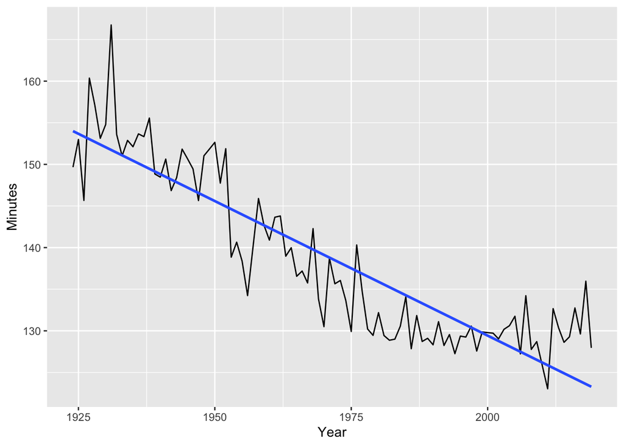

```r
boston_men |>
  ggplot(aes(x=Year,y=Minutes))+
  geom_line()+
  geom_smooth(method = "lm", se = FALSE)
```

```r
  labs(
    title = "Boston marathon winning times"
  )
```

```
## <ggplot2::labels> List of 1
##  $ title: chr "Boston marathon winning times"
```

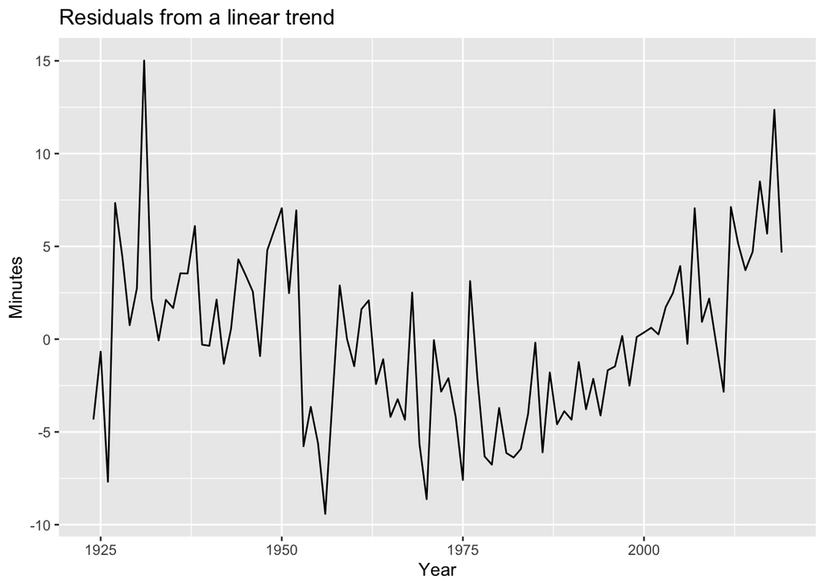

```r
fit <- lm(Minutes ~ Year, data = boston_men)

boston_men|>
  mutate(Residuals=residuals(fit)) |>
  ggplot(aes(x = Year, y = Residuals)) +
  geom_line(color = "black") +
  labs(
    title = "Residuals from a linear trend",
    y = "Minutes"
  )
```

Figure 7.20: Fitting a linear trend to the Boston marathon winning times is inadequate

#### 지수 추세 적합 (Exponential Trend)

- 로그-선형 회귀 모델을 통해 지수 추세를 적합할 수 있다:

$$\log(y_t) = \beta_0 + \beta_1 t + \varepsilon_t$$

- 이는 우승 시간이 **감소하되 점점 완만해지는 패턴**을 반영한다.
- Figure 7.21에서는 이 모델을 이용한 예측이 제시됨.
- **선형 추세보다 적합도는 비슷하지만, 미래 예측 관점에서는 더 타당한 형태**를 보인다.

#### 데이터 패턴의 변화

- 우승 기록 시계열은 세 구간으로 나뉜다:
  1. **~1950년**: 높은 변동성, 추세 거의 없음
  2. **1950~1980년**: 뚜렷한 감소 추세
  3. **1980년 이후**: **감소 정체(flattening)** 또는 **상승 조짐**

####. 구간별 선형 추세 (Piecewise Linear Trend)

- 이러한 변화를 설명하기 위해 **1950년과 1980년을 절단점(knots)**으로 설정
- 구간마다 다른 기울기를 갖는 **piecewise linear model**을 구성

⚠️ **주의사항**: 절단점의 주관적 설정은 **과적합(overfitting)**을 유발할 수 있으며,  
예측 성능을 저하시킬 수 있으므로 **신중하게 판단해야 한다.**

#### 결론

- 단순 선형 추세보다 **지수 추세 또는 절단점 기반 추세**가  
  더 현실적인 미래 예측을 가능하게 한다.
- 다만, 모델의 복잡도와 해석 가능성 사이의 균형이 필요하다.

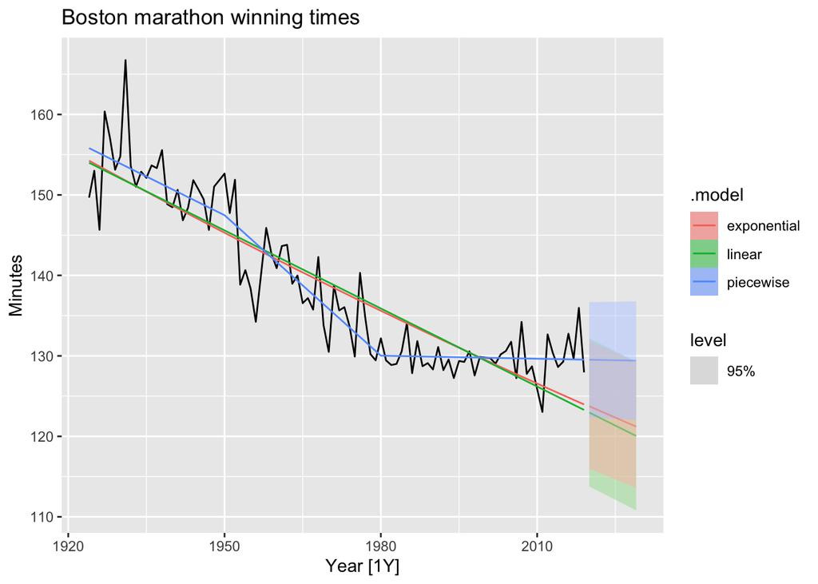

```r
fit_trends <- boston_men |>
  model(
    linear = TSLM(Minutes ~ trend()),
    exponential = TSLM(log(Minutes) ~ trend()),
    piecewise = TSLM(Minutes ~ trend(knots = c(1950, 1980)))
  )
fc_trends <- fit_trends |> forecast(h = 10)

boston_men |>
  autoplot(Minutes) +
  geom_line(data = fitted(fit_trends),
            aes(y = .fitted, colour = .model)) +
  autolayer(fc_trends, alpha = 0.5, level = 95) +
  labs(y = "Minutes",
       title = "Boston marathon winning times")
```

Figure 7.21: Projecting forecasts from linear, exponential and piecewise linear trends for the Boston marathon winning times.

Figure 7.21은 선형 추세, 지수 추세, 그리고 구간별 선형 추세로부터 적합된 선과 예측값을 보여준다. 가장 우수한 예측 결과는 **구간별 선형 추세(piecewise linear trend)**에서 나온 것으로 보인다.